# Week 12 - Regression

Natalie Kerr

Today, we’re going to be introducing how to run a linear regression. We will be using the lions data which measured the proportion of black in a male lion’s nose and the age of the lions. We want to know how proportion of the nose being black predicts age of lions. We will learn how to test assumptions for linear regression, write out linear equations, and plot model results.

```r
library(ggplot2)
library(ggformula)
```

# Load Data.

```r
lion <- read.csv("LionAge.csv")
head(lion)
```

|  | age | proportion.black |
| --- | --- | --- |
| 1 | 1.1 | 0.21 |
| 2 | 1.5 | 0.14 |
| 3 | 1.9 | 0.11 |
| 4 | 2.2 | 0.13 |
| 5 | 2.6 | 0.12 |
| 6 | 3.2 | 0.13 |

# Correlation review.

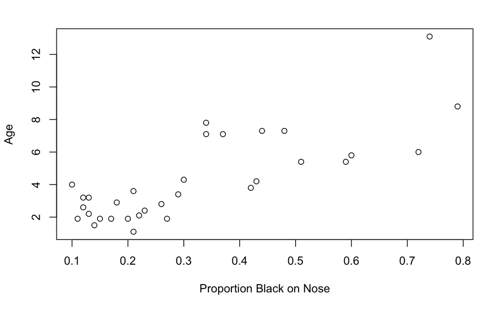

```r
plot(age ~ proportion.black, data = lion, xlab = "Proportion Black on Nose", ylab = "Age")
```

```r
cor <- cor.test(lion$proportion.black, lion$age, method = "pearson")
cor$estimate # Pearon correlation coefficient
```

```
      cor
0.7898272
```

```r
cor$estimate^2 # R-squared
```

```
     cor
0.623827
```

# Linear regression.

Plotting, running model, checking assumptions, and assessing model fit.

## Run Model

```r
m1 <- lm(age ~ proportion.black, data = lion) # lm stands for linear model, if proportion.black was a factor then it'd be running an ANOVA.
m1 # gives you the coefficients
```

```
Call:
lm(formula = age ~ proportion.black, data = lion)

Coefficients:
     (Intercept)  proportion.black
           0.879            10.647
```

## Plotting bivariate data with best fit line

We’ve learned to make scatter plots before. Now lets see how to add lines.

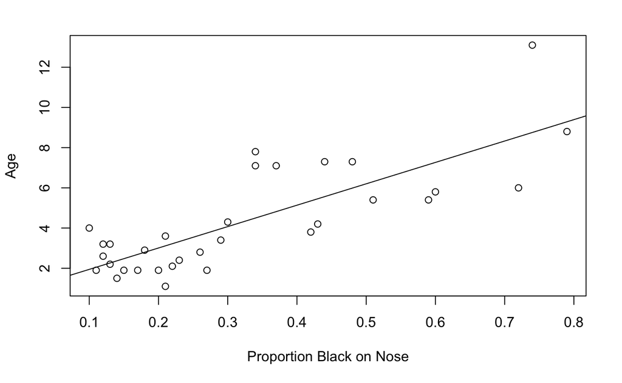

```r
plot(age ~ proportion.black, data = lion, xlab = "Proportion Black on Nose", ylab = "Age")
abline(m1)
```

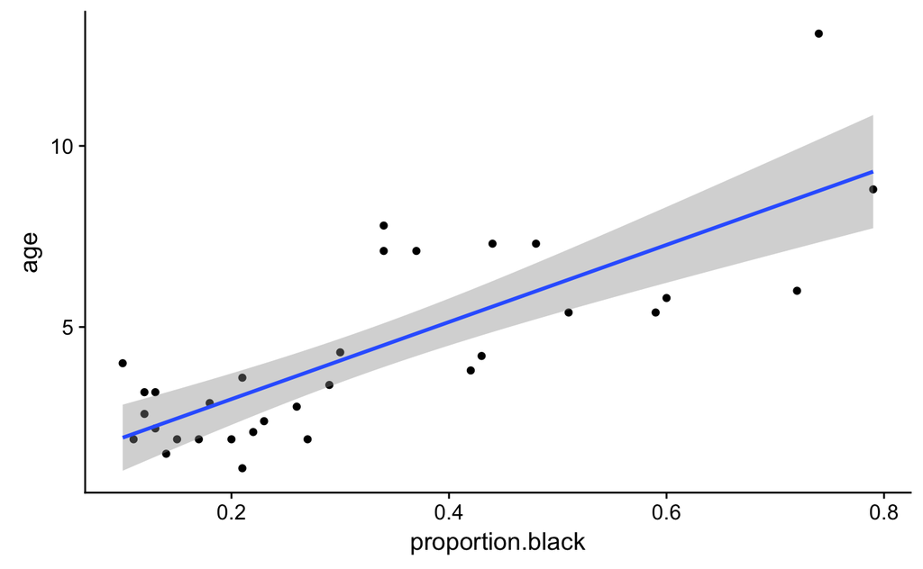

```r
# ggplot version
ggplot(lion, aes(x = proportion.black, y = age)) +
  geom_point() +
  geom_smooth(method = "lm", se = TRUE) # geom_smooth works for other models besides "lm", so you have to specify the method.  se = TRUE adds confidence bands.  Change it to FALSE if you just want a best-fit line
```

Note: The more complicated code Natalie showed in recitation for adding the line works for *any* kind of model, not just linear ones. This code is at the end of the notebook. But for linear models, the `abline()` shortcut is preferable.

## Check assumptions with residuals

### Residual plot

```r
# Save residuals to a column in original data frame for easy plotting
lion$residuals <- m1$residuals
mean(lion$residuals) # Mean of the residuals should be 0 (within rounding error)
```

```
[1] -1.734723e-18
```

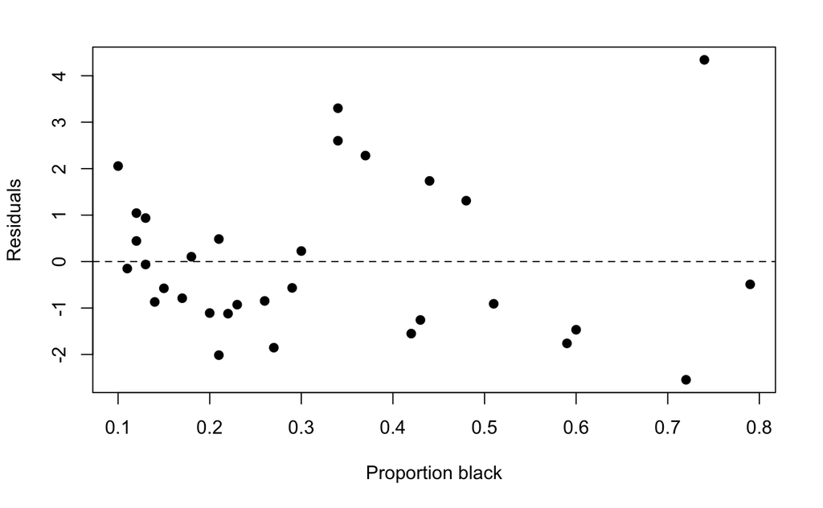

```r
# Residuals plot
plot(residuals ~ proportion.black, data = lion, pch = 19, xlab = "Proportion black", ylab = "Residuals")
abline(h = 0, lty = 2) #adds a horizontal line
```

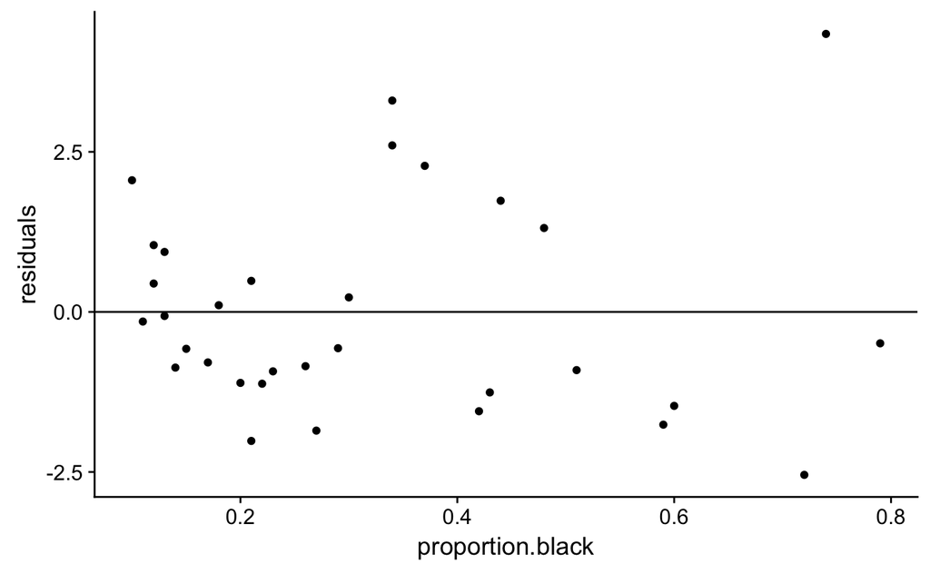

```r
# ggplot version
ggplot(lion) +
  geom_point(aes(x = proportion.black, y = residuals)) +
  geom_hline(aes(yintercept = 0))
```

### Q-Q plot

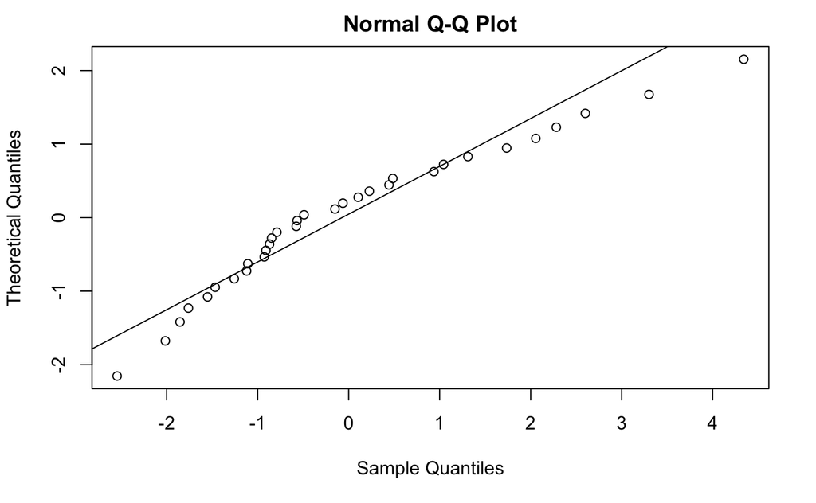

```r
qqnorm(lion$residuals, datax = TRUE)
qqline(lion$residuals, datax = TRUE)
```

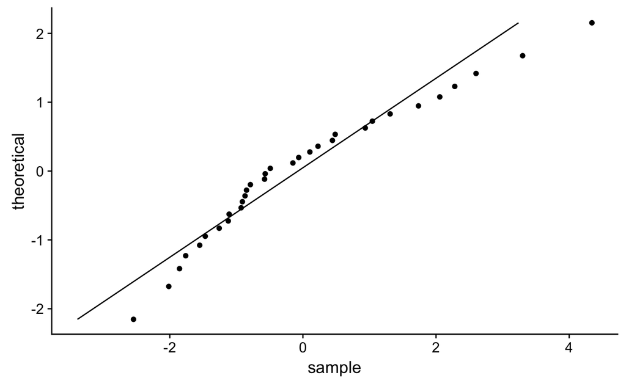

```r
#ggplot way
ggplot(lion, aes(sample = residuals)) +
  geom_qq() +
  stat_qqline() +
  coord_flip()
```

### Other diagnostics

Other diagnostic plots are available by just using `plot()` on your model object. You are not responsible for knowing these, but they will be useful if you do linear regressions in the future.

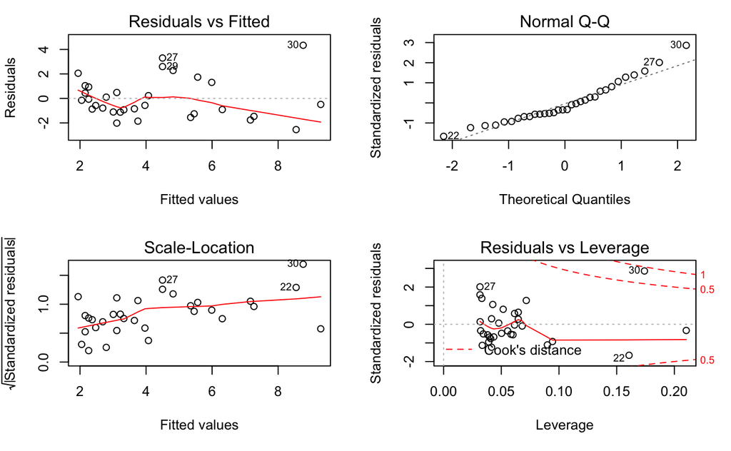

```r
par(mfrow=c(2,2)) #par() sets up graphical parameters. mfrow sets up a grid, in this case 2 x 2
plot(m1)  # 1. Residuals vs fitted - check to see if residuals are linear (and you can also check for homoscedasicity)
```

```r
          # 2. QQ plot - tests for normality
          # 3. Scale-location (OR residual plot) for homoscedasticity - horizontal line and equal spread.
          # 4. Residuals vs leverproportion.black - any influential outliers
# Find if their is a significant relationship between the variables
```

## Hypothesis testing regressions

The null hypothesis is that the slope is zero

You can do this hypothesis testing two ways. `anova()` gives you the ANOVA-like results

```r
anova(m1)
```

```
Analysis of Variance Table

Response: age
                 Df  Sum Sq Mean Sq F value    Pr(>F)
proportion.black  1 138.544 138.544  49.751 7.677e-08 ***
Residuals        30  83.543   2.785
---
Signif. codes:  0 ‘***’ 0.001 ‘**’ 0.01 ‘*’ 0.05 ‘.’ 0.1 ‘ ’ 1
```

From this output you get an F statistic (49.751), a p-value (p < 0.0001), and df (1, 30).

You can also get the t-test like results using `summary()`

```r
summary(m1)
```

```
Call:
lm(formula = age ~ proportion.black, data = lion)

Residuals:
    Min      1Q  Median      3Q     Max
-2.5449 -1.1117 -0.5285  0.9635  4.3421

Coefficients:
                 Estimate Std. Error t value Pr(>|t|)
(Intercept)        0.8790     0.5688   1.545    0.133
proportion.black  10.6471     1.5095   7.053 7.68e-08 ***
---
Signif. codes:  0 ‘***’ 0.001 ‘**’ 0.01 ‘*’ 0.05 ‘.’ 0.1 ‘ ’ 1

Residual standard error: 1.669 on 30 degrees of freedom
Multiple R-squared:  0.6238,    Adjusted R-squared:  0.6113
F-statistic: 49.75 on 1 and 30 DF,  p-value: 7.677e-08
```

```r
            # coefficients and their significance, are they different from 0.
            # R squared, and ajusted R-squared
            # F statistic and p-value
```

This gives coefficient (estimate), a standard error, a t-value, and their significance (Pr(>|t|)). This p-value tests whether the coefficient is significant from zero. **NOTE** Ignore the intercept! You almost never care about testing whether the intercept is different from zero.

This output also gives the R squared value (Multiple R-squared) and a short version of the ANOVA like results.

## Confidence intervals

You can calculate 95% confidence intervals for the slope using `confint()`

```r
confint(m1)
```

```
                      2.5 %    97.5 %
(Intercept)      -0.2826733  2.040686
proportion.black  7.5643082 13.729931
```

These are the upper and lower bounds of the 95% confidence interval. Again, you probably don’t care about the intercept!

# Exercise 1

*Data*: Bees were captured at night time to uniquely tag individual workers and measure their body size, intertegular span (mm) and body weight (g). During the day, tagged bees were captured upon returning to the colony. Pollen was collected and bees were weighed. Nectar weights (g) were calculated by the change in weight from day to night time.

*Instructions*:

1. Run a linear regression to investigate whether body size affects the nectar returns of worker bumble bees.
2. Create a residual plot.
3. Test other assumptions.
4. Assess model fit, and write out equation using coefficients.
5. Write summary statement.

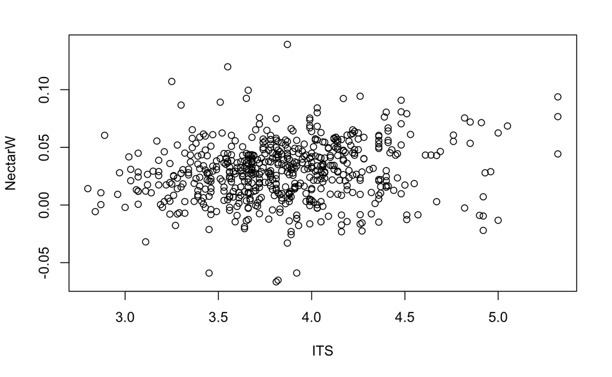

```r
resource <-readRDS("ResourceReturn.rds")
plot(NectarW ~ ITS, data = resource)
```

## Diagnostic plots

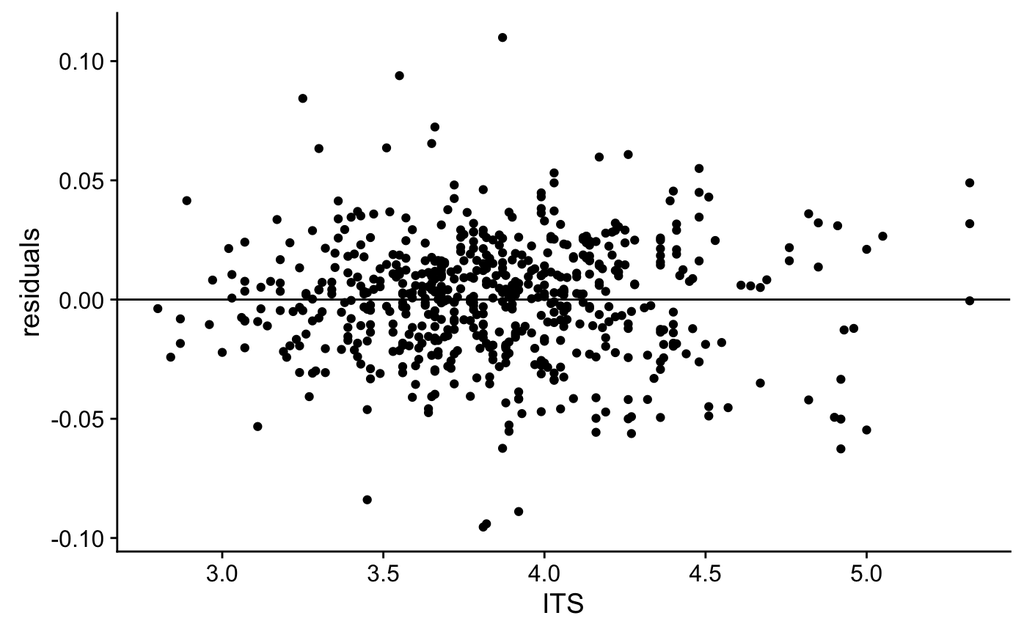

```r
r1 <- lm(NectarW ~ ITS , data = resource)
#extract residuals
resource$residuals <- r1$residuals
#residuals plot
ggplot(resource) +
  geom_point(aes(x = ITS, y = residuals)) +
  geom_hline(aes(yintercept = 0))
```

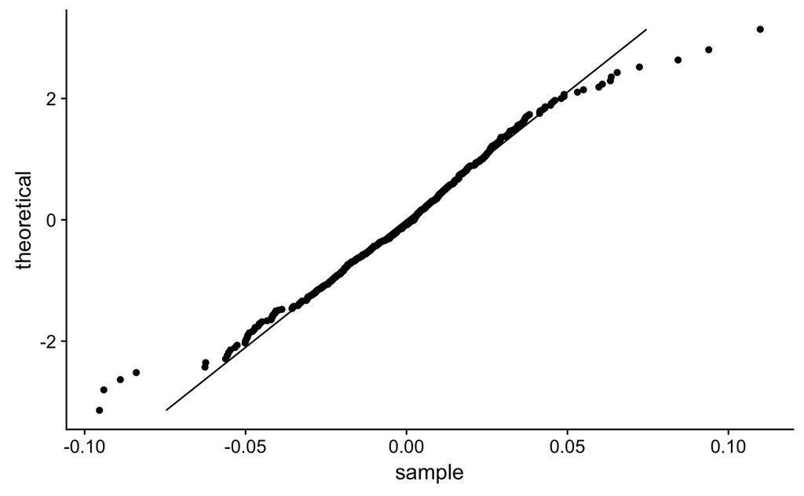

```r
#qq plot of residuals
ggplot(resource, aes(sample = residuals)) + #you can put the aes() inside ggplot() or inside the geom function
  geom_qq() +
  stat_qqline() +
  coord_flip()
```

Tails look not great. We could try a transformation.

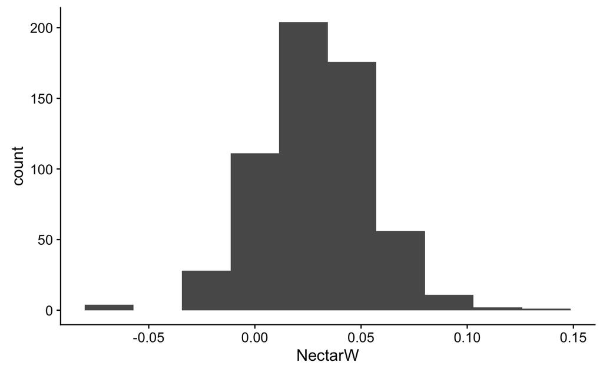

```r
ggplot(resource, aes(x = NectarW)) +
  geom_histogram(bins = 10)
```

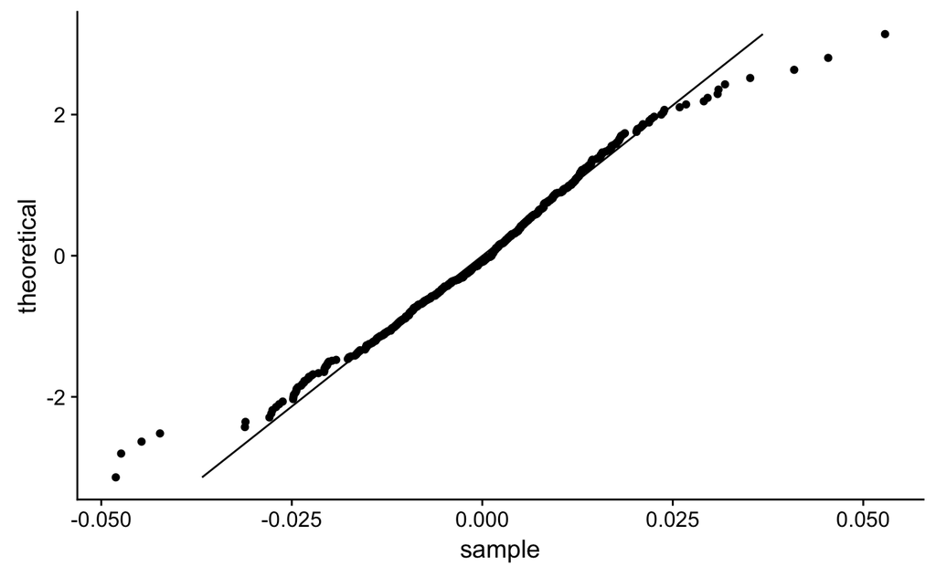

```r
#looks leptokurtic
#sqrt transformed nectar weights
r2 <- lm(sqrt(NectarW + 1) ~ ITS , data = resource) # add a constant to eliminate negative values so sqrt() works
resource$residuals2 <- r2$residuals
ggplot(resource, aes(sample = residuals2)) + #you can put the aes() inside ggplot() or inside the geom function
  geom_qq() +
  stat_qqline() +
  coord_flip()
```

Doesn’t make much of a difference. Let’s just move forward with the original model for now.

```r
anova(r1) # slope is significantly different from 0
```

```
Analysis of Variance Table

Response: NectarW
           Df  Sum Sq   Mean Sq F value    Pr(>F)
ITS         1 0.01140 0.0113975   18.02 2.538e-05 ***
Residuals 591 0.37381 0.0006325
---
Signif. codes:  0 ‘***’ 0.001 ‘**’ 0.01 ‘*’ 0.05 ‘.’ 0.1 ‘ ’ 1
```

```r
summary(r1) # does not explain a lot of the variation
```

```
Call:
lm(formula = NectarW ~ ITS, data = resource)

Residuals:
      Min        1Q    Median        3Q       Max
-0.095401 -0.016071  0.002292  0.015990  0.109890

Coefficients:
             Estimate Std. Error t value Pr(>|t|)
(Intercept) -0.011832   0.009700  -1.220    0.223
ITS          0.010652   0.002509   4.245 2.54e-05 ***
---
Signif. codes:  0 ‘***’ 0.001 ‘**’ 0.01 ‘*’ 0.05 ‘.’ 0.1 ‘ ’ 1

Residual standard error: 0.02515 on 591 degrees of freedom
Multiple R-squared:  0.02959,   Adjusted R-squared:  0.02795
F-statistic: 18.02 on 1 and 591 DF,  p-value: 2.538e-05
```

```r
coef(r1) # coefficients/model parameters
```

```
(Intercept)         ITS
-0.01183191  0.01065173
```

```r
confint(r1) # confidence interval for these parameters
```

```
                   2.5 %      97.5 %
(Intercept) -0.030882295 0.007218482
ITS          0.005723587 0.015579872
```

## Equation:

Use the coefficients from the model to write the linear equation.

y = -0.0118 + 0.0107x

# Exercise 2: Plotting model results

Plot the model output for the effect of ITS on nectar weights.

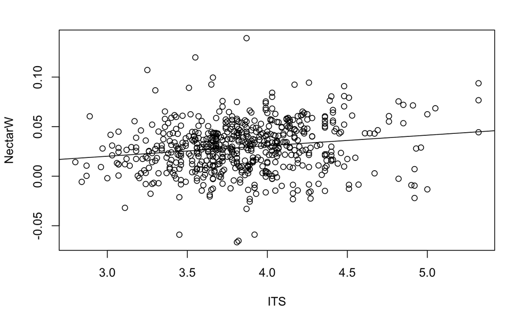

```r
#base R
plot(NectarW ~ ITS, data = resource)
abline(r1)
```

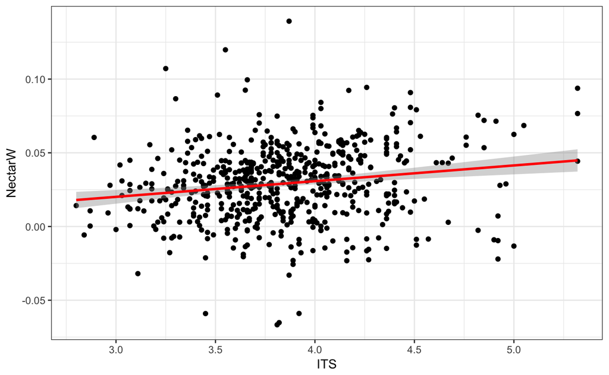

```r
#ggplot
ggplot(resource, aes(x = ITS, y = NectarW)) +
  geom_point() +
  geom_smooth(method = "lm", color = "red") + #change the line color if you want!
  theme_bw() #this just changes the background color from grey to white.
```

# Base R plotting of confidence bands and best-fit lines for ANY model.

```r
# Calculate predicted values
prop.vals <- seq(min(lion$proportion.black), max(lion$proportion.black), 0.01) # create a vector of predictor values
fun.lin <- coef(m1)[1] + coef(m1)[2]*prop.vals # calculate function from coefficients and predictor values
pred.lin <- predict(m1, newdata = data.frame(proportion.black = prop.vals), interval="confidence") # gives you predicted values (as above in line 147) and the lower and upper confidence intervals
# 1.1 Base R plotting using points() for line of best fit
with(lion,
     plot(proportion.black, age, pch = 19, xlab = "Proportion black", ylab = "Age (years)"))
points(prop.vals, fun.lin, type="l", lwd = 2) # line of best fit
```

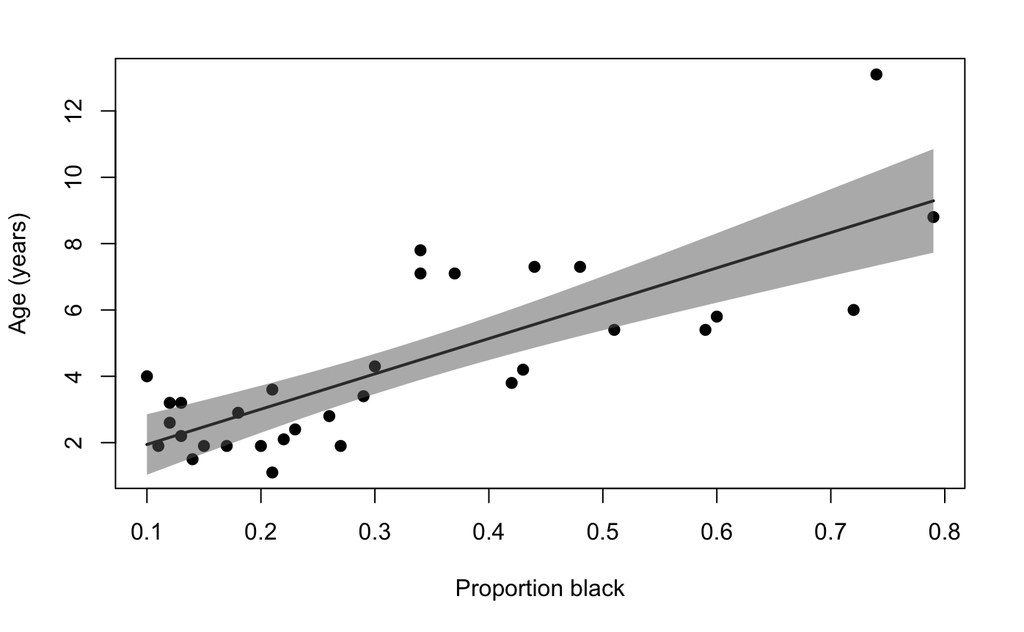

```r
polygon(c(rev(prop.vals), prop.vals), # define x with x and reverse of x
        c(rev(pred.lin[,2]), pred.lin[,3]),  # define y with y and reverse of y
        border = NA, col = adjustcolor("grey40", alpha = 0.5))
```